# DATA624_Homework5

John Ferrara

2025-03-07

## 1) Consider the the number of pigs slaughtered in Victoria, available in the aus_livestock dataset.

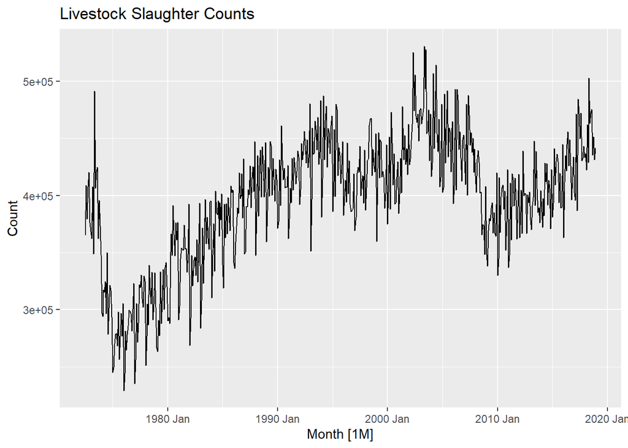

```r
#colnames(aus_livestock)
#unique(aus_livestock$Animal)

pigs <- aus_livestock |> filter(Animal=="Pigs") |> summarise(Count = sum(Count))

## Initial Plotting
pigs |>
  autoplot(Count) +
  labs(y = "Count", title = "Livestock Slaughter Counts")
```

#### a) Use the ETS() function to estimate the equivalent model for simple exponential smoothing. Find the optimal values of α and ℓ0, and generate forecasts for the next four months. Using the ETS modeling method with Simple Exponential Smoothing function, the optimal values for alpha and l0 are 2.229786e-01 and 3.885214e+05, respectively.

```r
fit <- pigs |>   model(ETS(Count ~ error("A") + trend("N") + season("N")))
## Seeing optimal values
print(tidy(fit))
```

```
## # A tibble: 2 × 3
##   .model                                                     term    estimate
##   <chr>                                                      <chr>      <dbl>
## 1 "ETS(Count ~ error(\"A\") + trend(\"N\") + season(\"N\"))" alpha      0.223
## 2 "ETS(Count ~ error(\"A\") + trend(\"N\") + season(\"N\"))" l[0]  388521.
```

```r
## Generating and Printing the forecast
fc <- fit |>  forecast(h = 4) #4 months
print(fc)
```

```
## # A fable: 4 x 4 [1M]
## # Key:     .model [1]
##   .model                                                        Month
##   <chr>                                                         <mth>
## 1 "ETS(Count ~ error(\"A\") + trend(\"N\") + season(\"N\"))" 2019 Jan
## 2 "ETS(Count ~ error(\"A\") + trend(\"N\") + season(\"N\"))" 2019 Feb
## 3 "ETS(Count ~ error(\"A\") + trend(\"N\") + season(\"N\"))" 2019 Mar
## 4 "ETS(Count ~ error(\"A\") + trend(\"N\") + season(\"N\"))" 2019 Apr
## # ℹ 2 more variables: Count <dist>, .mean <dbl>
```

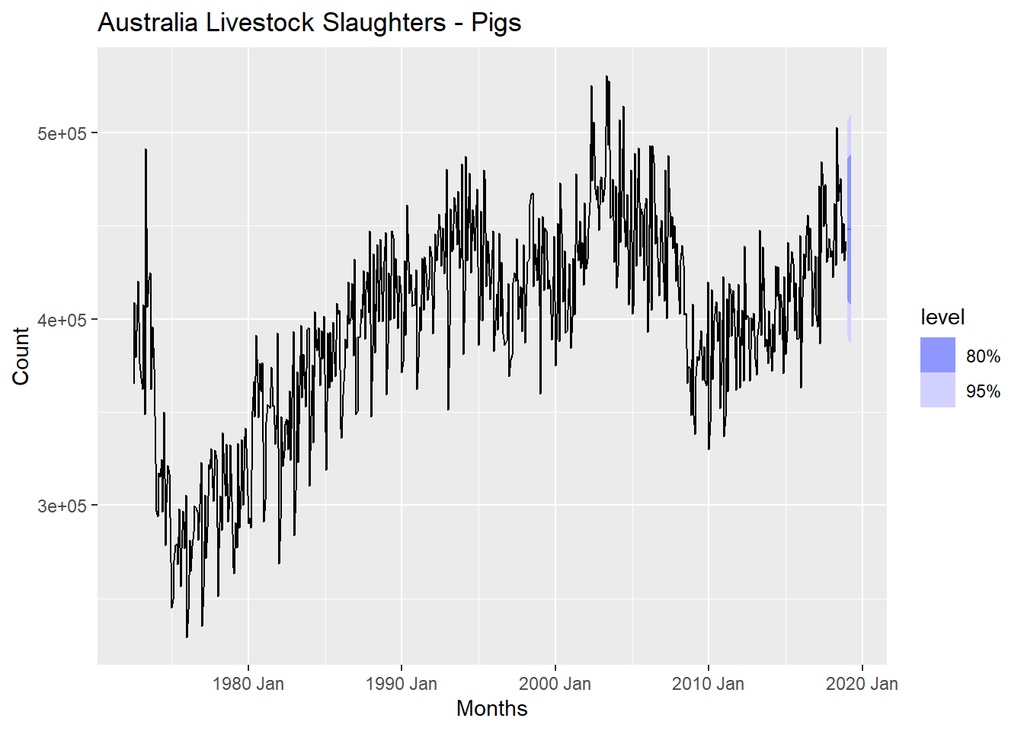

```r
#Plotting
fc |>
   autoplot(pigs) +
   labs(x="Months", y="Count",
       title = "Australia Livestock Slaughters - Pigs")
```

#### b) Compute a 95% prediction interval for the first forecast using ^y ± 1.96s where s is the standard deviation of the residuals. Compare your interval with the interval produced by R. The range of the prediction interval with a 95% confidence using the first mean prediction value is 390,388.7 through 506,012.1.

```r
## Taking the predicted values
first_predicted_mean_value <- fc$.mean[1] #(y^)
## Extracting Std. Dev from Counts
print(fc$Count[1])
```

```
## <distribution[1]>
## [1] N(448200, 8.7e+08)
```

```r
#<distribution[1]>
#[1] N(448200, 8.7e+08)
# Manually getting s
s <- sqrt(8.7e+08)
print(s)
```

```
## [1] 29495.76
```

```r
## Calculations with the formula
upper_lim <- first_predicted_mean_value + (1.96*s)
lower_lim <- first_predicted_mean_value - (1.96*s)
print(upper_lim)
```

```
## [1] 506012.1
```

```r
print(lower_lim)
```

```
## [1] 390388.7
```

## 5) Data set global_economy contains the annual Exports from many countries. Select one country to analyse.

#### a) Plot the Exports series and discuss the main features of the data.

When looking at the exports for Italy, there is a larger trend of increasing exports over the time covered by the chart. There isnt much seasonality in the chart, however the trend is not constant, there are downturns in the data - specifically in the 1980s there was a larger decreasing trend, which was reversed in the 1990s. Similarly, in 2008 there was a large decrease in exports.

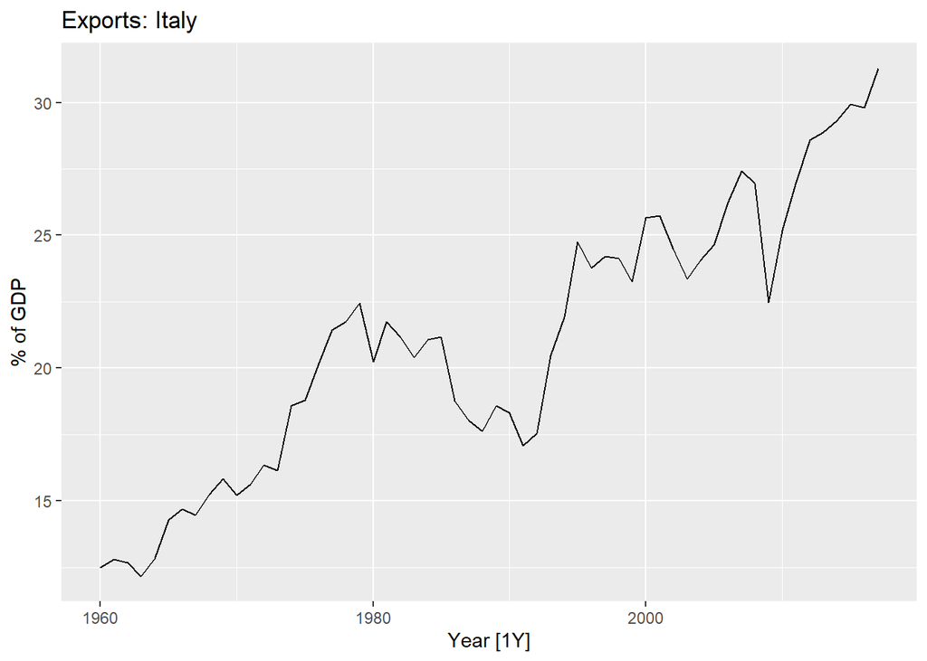

```r
italy_economy <- global_economy |>
  filter(Country == "Italy")

italy_economy |>
  autoplot(Exports) +
  labs(y = "% of GDP", title = "Exports: Italy")
```

#### b) Use an ETS(A,N,N) model to forecast the series, and plot the forecasts.

```r
fit <- italy_economy |> model(ETS(Exports ~ error("A") + trend("N") + season("N")))

## Seeing optimal values
print(tidy(fit))
```

```
## # A tibble: 2 × 4
##   Country .model                                                  term  estimate
##   <fct>   <chr>                                                   <chr>    <dbl>
## 1 Italy   "ETS(Exports ~ error(\"A\") + trend(\"N\") + season(\"… alpha     1.00
## 2 Italy   "ETS(Exports ~ error(\"A\") + trend(\"N\") + season(\"… l[0]     12.5
```

```r
## Generating and Printing the forecast
fc <- fit |>  forecast(h = 10) #10 years
print(fc)
```

```
## # A fable: 10 x 5 [1Y]
## # Key:     Country, .model [1]
##    Country .model                                                        Year
##    <fct>   <chr>                                                        <dbl>
##  1 Italy   "ETS(Exports ~ error(\"A\") + trend(\"N\") + season(\"N\"))"  2018
##  2 Italy   "ETS(Exports ~ error(\"A\") + trend(\"N\") + season(\"N\"))"  2019
##  3 Italy   "ETS(Exports ~ error(\"A\") + trend(\"N\") + season(\"N\"))"  2020
##  4 Italy   "ETS(Exports ~ error(\"A\") + trend(\"N\") + season(\"N\"))"  2021
##  5 Italy   "ETS(Exports ~ error(\"A\") + trend(\"N\") + season(\"N\"))"  2022
##  6 Italy   "ETS(Exports ~ error(\"A\") + trend(\"N\") + season(\"N\"))"  2023
##  7 Italy   "ETS(Exports ~ error(\"A\") + trend(\"N\") + season(\"N\"))"  2024
##  8 Italy   "ETS(Exports ~ error(\"A\") + trend(\"N\") + season(\"N\"))"  2025
##  9 Italy   "ETS(Exports ~ error(\"A\") + trend(\"N\") + season(\"N\"))"  2026
## 10 Italy   "ETS(Exports ~ error(\"A\") + trend(\"N\") + season(\"N\"))"  2027
## # ℹ 2 more variables: Exports <dist>, .mean <dbl>
```

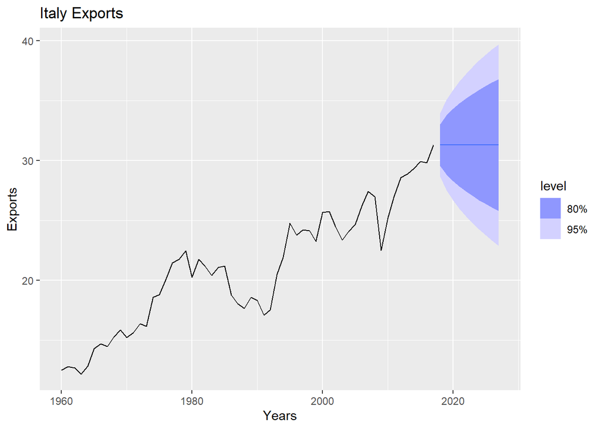

```r
#Plotting
fc |>
   autoplot(italy_economy) +
   labs(x="Years", y="Exports",
       title = "Italy Exports")
```

#### c) Compute the RMSE values for the training data.

Using the accuracy function the RMSE for the model for the training data is ~1.335.

```r
accuracy(fit)
```

```
## # A tibble: 1 × 11
##   Country .model        .type    ME  RMSE   MAE   MPE  MAPE  MASE RMSSE     ACF1
##   <fct>   <chr>         <chr> <dbl> <dbl> <dbl> <dbl> <dbl> <dbl> <dbl>    <dbl>
## 1 Italy   "ETS(Exports… Trai… 0.324  1.34  1.00  1.39  4.75 0.983 0.991 -0.00701
```

```r
# RMSE 1.335065
```